# Basic modelling and forecasting

# Specify and estimate

## Model specification

- Model specification in fable supports a formula based interface
- A model formula in R is expressed using `response ~ terms`
  - the formula’s left side describes the response
  - the right describes terms used to model the response.
- `Attention`: MODEL name is in capital letters, e.g. `SNAIVE`

## Model fitting: example

The `model()` function trains models on data.

```r
beer_fit <- aus_production |>
  model(
    `Seasonal_naïve` = SNAIVE(Beer),
    `Naïve` = NAIVE(Beer),
    Drift = RW(Beer ~ drift()),
    Mean = MEAN(Beer)
  )
```

```
# A mable: 1 x 4
  Seasonal_naïve   Naïve         Drift    Mean
         <model> <model>       <model> <model>
1       <SNAIVE> <NAIVE> <RW w/ drift>  <MEAN>
```

A `mable` is a model table, each cell corresponds to a fitted model.

## Extract information from `mable`

```r
beer_fit |> select(`Seasonal_naïve`) |> report()
beer_fit |> tidy()
beer_fit |> glance()
```

- The `report()` function gives a formatted model-specific display.
- The `tidy()` function is used to extract the coefficients from the models.
- We can extract information about some specific model using the `filter()` and `select()` functions.

# Produce forecasts

## Producing forecasts

- The `forecast()` function is used to produce forecasts from estimated models.
- **h** can be specified with:
  - a number (the number of future observations)
  - natural language (the length of time to predict)
  - provide a dataset of future time periods

## Producing forecasts

```r
beer_fc <- beer_fit |>
  forecast(h = "5 years")
```

```
# A fable: 80 x 4 [1Q]
# Key:     .model [4]
  .model Quarter        Beer .mean
  <chr>    <qtr>      <dist> <dbl>
1 Seaso… 2010 Q3 N(419, 373)   419
2 Seaso… 2010 Q4 N(488, 373)   488
3 Seaso… 2011 Q1 N(414, 373)   414
4 Seaso… 2011 Q2 N(374, 373)   374
# ℹ 76 more rows
```

A `fable` is a forecast table with point forecasts and distributions.

## Visualising forecasts

```r
beer_fc |>
  autoplot(aus_production, level = NULL) +
  labs(title = "Forecasts for quarterly beer production",
       x = "Quarter", y = "Megalitres") +
  guides(colour = guide_legend(title = "Forecast"))
```

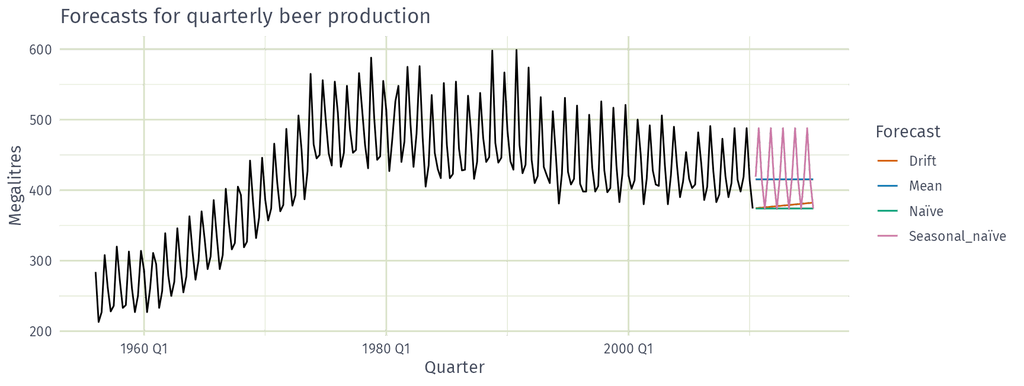

## Forecast distributions

- A forecast $\hat{y}_{T+h|T}$ is (usually) the mean of the conditional distribution $y_{T+h} \mid y_1, \dots, y_{T}$.
- Most time series models produce normally distributed forecasts.
- The forecast distribution describes the probability of observing any future value.

## Forecast distributions - normal distribution

Assuming residuals are normal, uncorrelated, sd = $\hat\sigma$:

| **Mean:** | $\hat{y}_{T+h\|T} \sim N(\bar{y}, (1 + 1/T)\hat{\sigma}^2)$ |
| --- | --- |
| **Naïve:** | $\hat{y}_{T+h\|T} \sim N(y_T, h\hat{\sigma}^2)$ |
| **Seasonal naïve:** | $\hat{y}_{T+h\|T} \sim N(y_{T+h-m(k+1)}, (k+1)\hat{\sigma}^2)$ |
| **Drift:** | $\hat{y}_{T+h\|T} \sim N(y_T + \frac{h}{T-1}(y_T - y_1),h\frac{T+h}{T}\hat{\sigma}^2)$ |

where $k$ is the integer part of $(h-1)/m$.

Note that when $h=1$ and $T$ is large, these all give the same approximate forecast variance: $\hat{\sigma}^2$.

## Forecast distributions from bootstrapping

When a normal distribution for the residuals is an unreasonable assumption, one alternative is to use bootstrapping, which only assumes that the residuals are uncorrelated with constant variance.

- A one-step forecast error is defined as $e_t = y_t - \hat{y}_{t|t-1}$, $y_t = \hat{y}_{t|t-1} + e_t.$
- So we can simulate the next observation of a time series using $y_{T+1} = \hat{y}_{T+1|T} + e_{T+1}$
- Adding the new simulated observation to our data set, we can repeat the process to obtain $y_{T+2} = \hat{y}_{T+2|T+1} + e_{T+2}$

## Generate many possible future using `generate()`

```r
beer_2000 <- aus_production |> filter(year(Quarter) >= 2000) |> select(Beer)
fit <- beer_2000 |>
  model(NAIVE(Beer))
set.seed(2024)
sim <- fit |> generate(h = 12, times = 5, bootstrap = TRUE)
sim
```

```
# A tsibble: 60 x 4 [1Q]
# Key:       .model, .rep [5]
   .model      Quarter .rep   .sim
   <chr>         <qtr> <chr> <dbl>
 1 NAIVE(Beer) 2010 Q3 1      387.
 2 NAIVE(Beer) 2010 Q4 1      371.
 3 NAIVE(Beer) 2011 Q1 1      327.
 4 NAIVE(Beer) 2011 Q2 1      276.
 5 NAIVE(Beer) 2011 Q3 1      237.
 6 NAIVE(Beer) 2011 Q4 1      258.
 7 NAIVE(Beer) 2012 Q1 1      215.
 8 NAIVE(Beer) 2012 Q2 1      316.
 9 NAIVE(Beer) 2012 Q3 1      262.
10 NAIVE(Beer) 2012 Q4 1      219.
# ℹ 50 more rows
```

## Generate 5 different futures

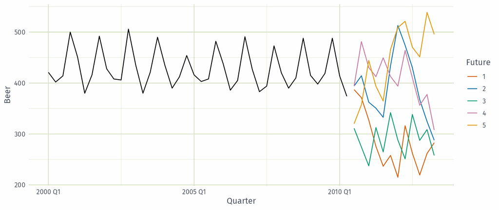

## Use `forecast()` function to generate probabilistic forecasts

```r
fc <- fit |> forecast(h = 12, bootstrap = TRUE)
fc
```

```
# A fable: 12 x 4 [1Q]
# Key:     .model [1]
   .model      Quarter         Beer .mean
   <chr>         <qtr>       <dist> <dbl>
 1 NAIVE(Beer) 2010 Q3 sample[5000]  374.
 2 NAIVE(Beer) 2010 Q4 sample[5000]  375.
 3 NAIVE(Beer) 2011 Q1 sample[5000]  375.
 4 NAIVE(Beer) 2011 Q2 sample[5000]  374.
 5 NAIVE(Beer) 2011 Q3 sample[5000]  374.
 6 NAIVE(Beer) 2011 Q4 sample[5000]  374.
 7 NAIVE(Beer) 2012 Q1 sample[5000]  375.
 8 NAIVE(Beer) 2012 Q2 sample[5000]  374.
 9 NAIVE(Beer) 2012 Q3 sample[5000]  376.
10 NAIVE(Beer) 2012 Q4 sample[5000]  376.
11 NAIVE(Beer) 2013 Q1 sample[5000]  375.
12 NAIVE(Beer) 2013 Q2 sample[5000]  375.
```

## Prediction intervals

- Forecast intervals can be extracted using the `hilo()` function.

```r
fit <- aus_production |> select(Beer) |> model(NAIVE(Beer))
forecast(fit) |> mutate(`95%` = hilo(Beer, 95))
```

```
# A fable: 8 x 5 [1Q]
# Key:     .model [1]
  .model Quarter          Beer .mean
  <chr>    <qtr>        <dist> <dbl>
1 NAIVE… 2010 Q3  N(374, 4580)   374
2 NAIVE… 2010 Q4  N(374, 9159)   374
3 NAIVE… 2011 Q1 N(374, 13739)   374
4 NAIVE… 2011 Q2 N(374, 18319)   374
5 NAIVE… 2011 Q3 N(374, 22898)   374
6 NAIVE… 2011 Q4 N(374, 27478)   374
7 NAIVE… 2012 Q1 N(374, 32057)   374
8 NAIVE… 2012 Q2 N(374, 36637)   374
# ℹ 1 more variable: `95%` <hilo>
```

## Prediction intervals

```r
beer_fc |>
  mutate(hilo(Beer, list(`50%` = 50, `75%` = 75)))
```

```
# A fable: 80 x 6 [1Q]
# Key:     .model [4]
   .model      Quarter         Beer
   <chr>         <qtr>       <dist>
 1 Seasonal_n… 2010 Q3  N(419, 373)
 2 Seasonal_n… 2010 Q4  N(488, 373)
 3 Seasonal_n… 2011 Q1  N(414, 373)
 4 Seasonal_n… 2011 Q2  N(374, 373)
 5 Seasonal_n… 2011 Q3  N(419, 747)
 6 Seasonal_n… 2011 Q4  N(488, 747)
 7 Seasonal_n… 2012 Q1  N(414, 747)
 8 Seasonal_n… 2012 Q2  N(374, 747)
 9 Seasonal_n… 2012 Q3 N(419, 1120)
10 Seasonal_n… 2012 Q4 N(488, 1120)
# ℹ 70 more rows
# ℹ 3 more variables: .mean <dbl>, `50%` <hilo>, `75%` <hilo>
```

## Prediction intervals

```r
beer_fc |>
  mutate(`50%` = hilo(Beer, 50)) |>
  mutate(lower = `50%`$lower, upper = `50%`$upper)
```

```
# A fable: 80 x 7 [1Q]
# Key:     .model [4]
   .model      Quarter         Beer
   <chr>         <qtr>       <dist>
 1 Seasonal_n… 2010 Q3  N(419, 373)
 2 Seasonal_n… 2010 Q4  N(488, 373)
 3 Seasonal_n… 2011 Q1  N(414, 373)
 4 Seasonal_n… 2011 Q2  N(374, 373)
 5 Seasonal_n… 2011 Q3  N(419, 747)
 6 Seasonal_n… 2011 Q4  N(488, 747)
 7 Seasonal_n… 2012 Q1  N(414, 747)
 8 Seasonal_n… 2012 Q2  N(374, 747)
 9 Seasonal_n… 2012 Q3 N(419, 1120)
10 Seasonal_n… 2012 Q4 N(488, 1120)
# ℹ 70 more rows
# ℹ 4 more variables: .mean <dbl>, `50%` <hilo>, lower <dbl>, upper <dbl>
```

# Fitted values and residuals

## Fitted values

- $\hat{y}_{t|t-1}$ is the forecast of $y_t$ based on observations $y_1,\dots,y_{t-1}$.
- We call these “fitted values”.
- Sometimes drop the subscript: $\hat{y}_t \equiv \hat{y}_{t|t-1}$.
- Often not true forecasts since parameters are estimated on all data.

### For example:

- $\hat{y}_{t} = \bar{y}$ for average method.
- $\hat{y}_{t} = y_{t-1} + (y_{T}-y_1)/(T-1)$ for drift method.

## Forecasting residuals

**Residuals in forecasting:** difference between observed value and its fitted value: $e_t = y_t-\hat{y}_{t|t-1}$.

## Beer production - augment

```r
fit <- aus_production |> select(Beer) |> model(SNAIVE(Beer))
augment(fit)
```

```
# A tsibble: 218 x 6 [1Q]
# Key:       .model [1]
   .model       Quarter  Beer .fitted .resid .innov
   <chr>          <qtr> <dbl>   <dbl>  <dbl>  <dbl>
 1 SNAIVE(Beer) 1956 Q1   284      NA     NA     NA
 2 SNAIVE(Beer) 1956 Q2   213      NA     NA     NA
 3 SNAIVE(Beer) 1956 Q3   227      NA     NA     NA
 4 SNAIVE(Beer) 1956 Q4   308      NA     NA     NA
 5 SNAIVE(Beer) 1957 Q1   262     284    -22    -22
 6 SNAIVE(Beer) 1957 Q2   228     213     15     15
 7 SNAIVE(Beer) 1957 Q3   236     227      9      9
 8 SNAIVE(Beer) 1957 Q4   320     308     12     12
 9 SNAIVE(Beer) 1958 Q1   272     262     10     10
10 SNAIVE(Beer) 1958 Q2   233     228      5      5
# ℹ 208 more rows
```

## Beer production - fitted values

```r
augment(fit) |>
  ggplot(aes(x = Quarter)) +
  geom_line(aes(y = Beer, colour = "Data")) +
  geom_line(aes(y = .fitted, colour = "Fitted"))
```

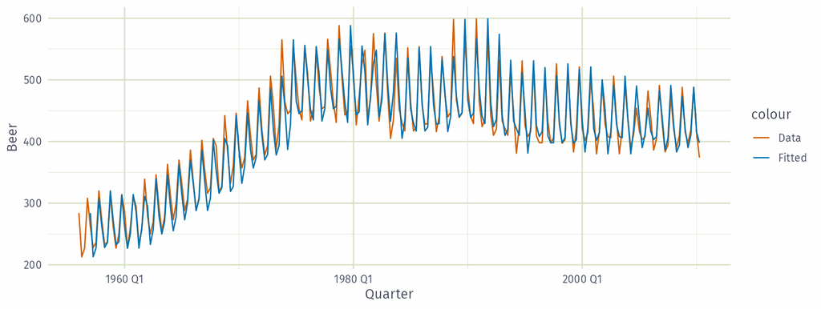

## Beer production - residuals

```r
augment(fit) |>
  autoplot(.resid) +
  labs(x = "Quarter", y = "", title = "Residuals from snaïve method")
```

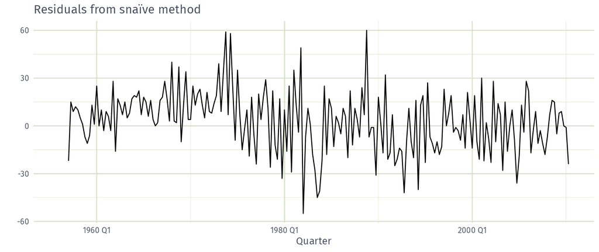

## Beer production - residual ACF

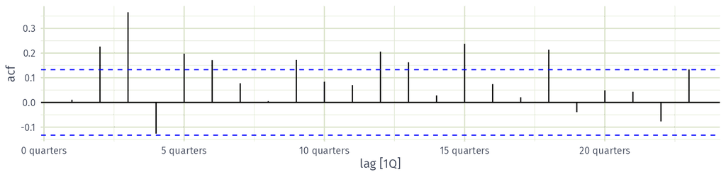

```r
augment(fit) |> ACF(.resid) |> autoplot()
```

These residuals look like random noise

*Scale: Strongly disagree · Disagree · Neutral · Agree · Strongly agree*